# Python - Day 1

# 1 Introduction

The aim for day 1 of the Intro to Python workshop is to explore the AMES dataset, and familiarise graduates with some of the core elements needed for data science projects.

The session will be guided, meaning that each topic will be explored together. Should learners want to progress through it at a faster pace then there are challenges that can be attempted at the end of the notebook.

The first thing we need to do is import some packages for us in the session. Python is open source and as such can draw on a wide range of packages created to undertake specific tasks. For the purposes of this training, we’ll stick with Pandas and Numpy.

```python
# Import pandas and numpy packages and give them an alias each
import pandas as pd
import numpy as np
```

We then need to add in the dataset we’ll be using. First we create a folder in our working directory called “data” and copy our csv file into it.

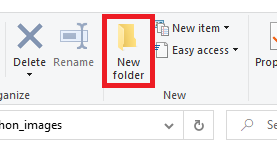

Creating a folder called “data”

Once our data has been copied into the new folder we need to load it into our Python environment.

```python
ames_data = pd.read_csv('./data/ames.csv')
```

# 2 Previewing data

Pandas has several ways to take a quick look at data, so let’s make use of them to familiarise ourselves with the data we just read in.

```python
# View head of the data
ames_data.head(10)
```

|  | Order | MS SubClass | MS Zoning | Lot Frontage | Lot Area | Street | Alley | Lot Shape | Land Contour | Utilities | ... | Pool Area | Pool QC | Fence | Misc Feature | Misc Val | Mo Sold | Yr Sold | Sale Type | Sale Condition | SalePrice |
| --- | --- | --- | --- | --- | --- | --- | --- | --- | --- | --- | --- | --- | --- | --- | --- | --- | --- | --- | --- | --- | --- |
| 0 | 1 | 20 | RL | 141.0 | 31770 | Pave | NaN | IR1 | Lvl | AllPub | ... | 0 | NaN | NaN | NaN | 0 | 5 | 2010 | WD | Normal | 215000 |
| 1 | 2 | 20 | RH | 80.0 | 11622 | Pave | NaN | Reg | Lvl | AllPub | ... | 0 | NaN | MnPrv | NaN | 0 | 6 | 2010 | WD | Normal | 105000 |
| 2 | 3 | 20 | RL | 81.0 | 14267 | Pave | NaN | IR1 | Lvl | AllPub | ... | 0 | NaN | NaN | Gar2 | 12500 | 6 | 2010 | WD | Normal | 172000 |
| 3 | 4 | 20 | RL | 93.0 | 11160 | Pave | NaN | Reg | Lvl | AllPub | ... | 0 | NaN | NaN | NaN | 0 | 4 | 2010 | WD | Normal | 244000 |
| 4 | 5 | 60 | RL | 74.0 | 13830 | Pave | NaN | IR1 | Lvl | AllPub | ... | 0 | NaN | MnPrv | NaN | 0 | 3 | 2010 | WD | Normal | 189900 |
| 5 | 6 | 60 | RL | 78.0 | 9978 | Pave | NaN | IR1 | Lvl | AllPub | ... | 0 | NaN | NaN | NaN | 0 | 6 | 2010 | WD | Normal | 195500 |
| 6 | 7 | 120 | RL | 41.0 | 4920 | Pave | NaN | Reg | Lvl | AllPub | ... | 0 | NaN | NaN | NaN | 0 | 4 | 2010 | WD | Normal | 213500 |
| 7 | 8 | 120 | RL | 43.0 | 5005 | Pave | NaN | IR1 | HLS | AllPub | ... | 0 | NaN | NaN | NaN | 0 | 1 | 2010 | WD | Normal | 191500 |
| 8 | 9 | 120 | RL | 39.0 | 5389 | Pave | NaN | IR1 | Lvl | AllPub | ... | 0 | NaN | NaN | NaN | 0 | 3 | 2010 | WD | Normal | 236500 |
| 9 | 10 | 60 | RL | 60.0 | 7500 | Pave | NaN | Reg | Lvl | AllPub | ... | 0 | NaN | NaN | NaN | 0 | 6 | 2010 | WD | Normal | 189000 |

10 rows × 81 columns

```python
# View tail of the data
ames_data.tail()
```

|  | Order | MS SubClass | MS Zoning | Lot Frontage | Lot Area | Street | Alley | Lot Shape | Land Contour | Utilities | ... | Pool Area | Pool QC | Fence | Misc Feature | Misc Val | Mo Sold | Yr Sold | Sale Type | Sale Condition | SalePrice |
| --- | --- | --- | --- | --- | --- | --- | --- | --- | --- | --- | --- | --- | --- | --- | --- | --- | --- | --- | --- | --- | --- |
| 2925 | 2926 | 80 | RL | 37.0 | 7937 | Pave | NaN | IR1 | Lvl | AllPub | ... | 0 | NaN | GdPrv | NaN | 0 | 3 | 2006 | WD | Normal | 142500 |
| 2926 | 2927 | 20 | RL | NaN | 8885 | Pave | NaN | IR1 | Low | AllPub | ... | 0 | NaN | MnPrv | NaN | 0 | 6 | 2006 | WD | Normal | 131000 |
| 2927 | 2928 | 85 | RL | 62.0 | 10441 | Pave | NaN | Reg | Lvl | AllPub | ... | 0 | NaN | MnPrv | Shed | 700 | 7 | 2006 | WD | Normal | 132000 |
| 2928 | 2929 | 20 | RL | 77.0 | 10010 | Pave | NaN | Reg | Lvl | AllPub | ... | 0 | NaN | NaN | NaN | 0 | 4 | 2006 | WD | Normal | 170000 |
| 2929 | 2930 | 60 | RL | 74.0 | 9627 | Pave | NaN | Reg | Lvl | AllPub | ... | 0 | NaN | NaN | NaN | 0 | 11 | 2006 | WD | Normal | 188000 |

5 rows × 81 columns

```python
# The shape of the data frame
# (num rows, num columns)
ames_data.shape
```

```
(2930, 81)
```

```python
# The types of data in each column
ames_data.info()
```

```
<class 'pandas.core.frame.DataFrame'>
RangeIndex: 2930 entries, 0 to 2929
Data columns (total 81 columns):
 #   Column           Non-Null Count  Dtype
---  ------           --------------  -----
 0   Order            2930 non-null   int64
 1   MS SubClass      2930 non-null   int64
 2   MS Zoning        2930 non-null   object
 3   Lot Frontage     2440 non-null   float64
 4   Lot Area         2930 non-null   int64
 5   Street           2930 non-null   object
 6   Alley            198 non-null    object
 7   Lot Shape        2930 non-null   object
 8   Land Contour     2930 non-null   object
 9   Utilities        2930 non-null   object
```

[output cut: 73 more lines]

# 3 Renaming columns

It’s common practice to format column names and variables in certain ways. The most common format for these is called snake case where all the letters are lower case and the spaces are replaced with underscores. With snake case all the characters are “low” like a snake is close_to_the_ground.

Other case types are:

- **Kebab case**: this-is-a-kebab
- **Camel case**: notRealCamels

You can read more about case-types in this article at freeCodeCamp: [Snake Case VS Camel Case VS Pascal Case VS Kebab Case – What’s the Difference Between Casings?](https://www.freecodecamp.org/news/snake-case-vs-camel-case-vs-pascal-case-vs-kebab-case-whats-the-difference/)

We’re going to rename our columns to snake case. If you look at the column names in the output of the `.info()` command you can see they all contain capital letters and some contain spaces. We can change that with just a couple of lines of code.

```python
# Change column names to lower case
ames_data.columns = [col.lower() for col in ames_data.columns]

# Replace spaces in column names
ames_data.columns = [col.replace(' ', '_') for col in ames_data.columns]

ames_data.columns
```

```
Index(['order', 'ms_subclass', 'ms_zoning', 'lot_frontage', 'lot_area',
       'street', 'alley', 'lot_shape', 'land_contour', 'utilities',
       'lot_config', 'land_slope', 'neighborhood', 'condition_1',
       'condition_2', 'bldg_type', 'house_style', 'overall_qual',
       'overall_cond', 'year_built', 'year_remod/add', 'roof_style',
       'roof_matl', 'exterior_1st', 'exterior_2nd', 'mas_vnr_type',
       'mas_vnr_area', 'exter_qual', 'exter_cond', 'foundation', 'bsmt_qual',
       'bsmt_cond', 'bsmt_exposure', 'bsmtfin_type_1', 'bsmtfin_sf_1',
       'bsmtfin_type_2', 'bsmtfin_sf_2', 'bsmt_unf_sf', 'total_bsmt_sf',
       'heating', 'heating_qc', 'central_air', 'electrical', '1st_flr_sf',
       '2nd_flr_sf', 'low_qual_fin_sf', 'gr_liv_area', 'bsmt_full_bath',
       'bsmt_half_bath', 'full_bath', 'half_bath', 'bedroom_abvgr',
       'kitchen_abvgr', 'kitchen_qual', 'totrms_abvgrd', 'functional',
       'fireplaces', 'fireplace_qu', 'garage_type', 'garage_yr_blt',
       'garage_finish', 'garage_cars', 'garage_area', 'garage_qual',
       'garage_cond', 'paved_drive', 'wood_deck_sf', 'open_porch_sf',
       'enclosed_porch', '3ssn_porch', 'screen_porch', 'pool_area', 'pool_qc',
       'fence', 'misc_feature', 'misc_val', 'mo_sold', 'yr_sold', 'sale_type',
       'sale_condition', 'saleprice'],
      dtype='object')
```

Another way to remane columns is to use a `dictionary` to explicitly state what you want a column renamed as.

```python
ames_data.rename(columns = {'exter_qual': 'exterior_quality', 'exter_cond': 'exterior_condition'}, inplace = True)
ames_data.columns
```

```
Index(['order', 'ms_subclass', 'ms_zoning', 'lot_frontage', 'lot_area',
       'street', 'alley', 'lot_shape', 'land_contour', 'utilities',
       'lot_config', 'land_slope', 'neighborhood', 'condition_1',
       'condition_2', 'bldg_type', 'house_style', 'overall_qual',
       'overall_cond', 'year_built', 'year_remod/add', 'roof_style',
       'roof_matl', 'exterior_1st', 'exterior_2nd', 'mas_vnr_type',
       'mas_vnr_area', 'exterior_quality', 'exterior_condition', 'foundation',
       'bsmt_qual', 'bsmt_cond', 'bsmt_exposure', 'bsmtfin_type_1',
       'bsmtfin_sf_1', 'bsmtfin_type_2', 'bsmtfin_sf_2', 'bsmt_unf_sf',
       'total_bsmt_sf', 'heating', 'heating_qc', 'central_air', 'electrical',
       '1st_flr_sf', '2nd_flr_sf', 'low_qual_fin_sf', 'gr_liv_area',
       'bsmt_full_bath', 'bsmt_half_bath', 'full_bath', 'half_bath',
       'bedroom_abvgr', 'kitchen_abvgr', 'kitchen_qual', 'totrms_abvgrd',
       'functional', 'fireplaces', 'fireplace_qu', 'garage_type',
       'garage_yr_blt', 'garage_finish', 'garage_cars', 'garage_area',
       'garage_qual', 'garage_cond', 'paved_drive', 'wood_deck_sf',
       'open_porch_sf', 'enclosed_porch', '3ssn_porch', 'screen_porch',
       'pool_area', 'pool_qc', 'fence', 'misc_feature', 'misc_val', 'mo_sold',
       'yr_sold', 'sale_type', 'sale_condition', 'saleprice'],
      dtype='object')
```

# 4 Selecting data

In most situations you’ll want to select parts of your data that meet certain criteria for further analysis. When you receive data you’ll often want to only look at the relevant columns so we’ll look at how to do that, and different ways to select rows.

## 4.1 Selecting columns

### 4.1.1 Single columns

```python
street = ames_data['street']
type(street)
```

```
pandas.core.series.Series
```

```python
street = ames_data[['street']]
type(street)
```

```
pandas.core.frame.DataFrame
```

### 4.1.2 Multiple columns

When selecting columns you’ll often want to use the `.copy()` command. Without it the above variable will only hold a reference to those columns, not the columns separate to the original whole data. This would then produce warnings when you try to transform the data. Here is an example:

```python
ames_df = ames_data[['lot_area', 'neighborhood', 'yr_sold', 'saleprice']]
ames_df['lot_area'] = 12
```

```
d:\documents\projects\learning\intermediate_nlp\lib\site-packages\ipykernel_launcher.py:2: SettingWithCopyWarning:
A value is trying to be set on a copy of a slice from a DataFrame.
Try using .loc[row_indexer,col_indexer] = value instead

See the caveats in the documentation: https://pandas.pydata.org/pandas-docs/stable/user_guide/indexing.html#returning-a-view-versus-a-copy
```

This can result in you making unwanted changes to the original data, not on an extract of that data. Therefore, you often want to use the `.copy()` when selecting parts of a dataset. We will do this for the columns we’ll use for the remainder of this session.

```python
ames_df = ames_data[['lot_area', 'neighborhood', 'yr_sold', 'saleprice']].copy()
ames_df['lot_area'] = 12
```

## 4.2 Selecting rows

### 4.2.1 By index

Each row in our data is incrementally numbered and is called the index. In our Jupyter notebook this is shown in bold. This can be modified in different ways but we won’t be focussing on that here.

We can select specific rows by using the `.iloc()` method (index location), separating our start and end indices with a colon `:`

The selection goes up to but not including the last number. So selecting 100 rows starting at row 1400 is as follows:

```python
# Select rows 1400 - 1499
ames_df_slice = ames_df.iloc[1400:1500]

# Check the shape of the result
ames_df_slice.shape
```

```
(100, 4)
```

```python
# Double check our index starts where we specified
ames_df_slice.head()
```

|  | lot_area | neighborhood | yr_sold | saleprice |
| --- | --- | --- | --- | --- |
| 1400 | 12 | ClearCr | 2008 | 245000 |
| 1401 | 12 | ClearCr | 2008 | 241500 |
| 1402 | 12 | ClearCr | 2008 | 256000 |
| 1403 | 12 | Edwards | 2008 | 177000 |
| 1404 | 12 | Edwards | 2008 | 125600 |

```python
# Double check our index ends where we specified
ames_df_slice.tail()
```

|  | lot_area | neighborhood | yr_sold | saleprice |
| --- | --- | --- | --- | --- |
| 1495 | 12 | Edwards | 2008 | 160500 |
| 1496 | 12 | Edwards | 2008 | 176000 |
| 1497 | 12 | Edwards | 2008 | 284700 |
| 1498 | 12 | Edwards | 2008 | 160000 |
| 1499 | 12 | Edwards | 2008 | 148000 |

## 4.3 Selecting data conditionally

Filtering data by selecting based on a condition is critical to good analysis of data. You can select on single or multiple conditions, use standard comparitors such as “less than”, and nest conditions.

### 4.3.1 Single condition

```python
# Select all properties sold in 2010
sold_2010 = ames_df[ames_df['yr_sold'] == 2010]
sold_2010.head()
```

|  | lot_area | neighborhood | yr_sold | saleprice |
| --- | --- | --- | --- | --- |
| 0 | 12 | NAmes | 2010 | 215000 |
| 1 | 12 | NAmes | 2010 | 105000 |
| 2 | 12 | NAmes | 2010 | 172000 |
| 3 | 12 | NAmes | 2010 | 244000 |
| 4 | 12 | Gilbert | 2010 | 189900 |

### 4.3.2 Multiple conditions

```python
# Select all properties sold in 2010 for less than 100,000
sold_2010_under_100k = ames_df[(ames_df['yr_sold'] == 2010) & (ames_df['saleprice'] < 100000)]
sold_2010_under_100k.head()
```

|  | lot_area | neighborhood | yr_sold | saleprice |
| --- | --- | --- | --- | --- |
| 29 | 12 | BrDale | 2010 | 96000 |
| 31 | 12 | BrDale | 2010 | 88000 |
| 77 | 12 | SawyerW | 2010 | 99500 |
| 82 | 12 | SawyerW | 2010 | 67500 |
| 125 | 12 | NAmes | 2010 | 84900 |

We can also use the `.isin()` method to match values within a given list or tuple

```python
# Select all properties sold in 2010 that are in specific neighborhoods
selected_neighborhoods = ['Blmngtn', 'StoneBr', 'Somerst'] # List of neighborhoods
sold_2010_neighborhood = ames_df[(ames_df['yr_sold'] == 2010) & (ames_df['neighborhood'].isin(selected_neighborhoods))]
sold_2010_neighborhood.head(10)
```

|  | lot_area | neighborhood | yr_sold | saleprice |
| --- | --- | --- | --- | --- |
| 6 | 12 | StoneBr | 2010 | 213500 |
| 7 | 12 | StoneBr | 2010 | 191500 |
| 8 | 12 | StoneBr | 2010 | 236500 |
| 14 | 12 | StoneBr | 2010 | 212000 |
| 15 | 12 | StoneBr | 2010 | 538000 |
| 17 | 12 | StoneBr | 2010 | 394432 |
| 22 | 12 | Somerst | 2010 | 216000 |
| 52 | 12 | Blmngtn | 2010 | 160000 |
| 53 | 12 | Blmngtn | 2010 | 192000 |
| 66 | 12 | Somerst | 2010 | 221500 |

# 5 Sorting data

The data we just selected is in the order of it’s index, but we may want it in a different order so we can see similar entries together. We can specify what columns we want to sort by, and the direction we want to sort them.

```python
sold_2010_neighborhood.sort_values(by = 'neighborhood',
                                   ascending = False)
```

|  | lot_area | neighborhood | yr_sold | saleprice |
| --- | --- | --- | --- | --- |
| 6 | 12 | StoneBr | 2010 | 213500 |
| 8 | 12 | StoneBr | 2010 | 236500 |
| 14 | 12 | StoneBr | 2010 | 212000 |
| 15 | 12 | StoneBr | 2010 | 538000 |
| 17 | 12 | StoneBr | 2010 | 394432 |
| 7 | 12 | StoneBr | 2010 | 191500 |
| 100 | 12 | Somerst | 2010 | 177500 |
| 97 | 12 | Somerst | 2010 | 149500 |
| 98 | 12 | Somerst | 2010 | 152000 |
| 99 | 12 | Somerst | 2010 | 222000 |
| 103 | 12 | Somerst | 2010 | 147110 |
| 101 | 12 | Somerst | 2010 | 177000 |
| 102 | 12 | Somerst | 2010 | 155000 |
| 95 | 12 | Somerst | 2010 | 155000 |
| 104 | 12 | Somerst | 2010 | 267916 |
| 105 | 12 | Somerst | 2010 | 254000 |
| 96 | 12 | Somerst | 2010 | 151000 |
| 71 | 12 | Somerst | 2010 | 271500 |
| 94 | 12 | Somerst | 2010 | 190000 |
| 93 | 12 | Somerst | 2010 | 260000 |
| 70 | 12 | Somerst | 2010 | 254900 |
| 69 | 12 | Somerst | 2010 | 262500 |
| 68 | 12 | Somerst | 2010 | 215200 |
| 67 | 12 | Somerst | 2010 | 204500 |
| 66 | 12 | Somerst | 2010 | 221500 |
| 22 | 12 | Somerst | 2010 | 216000 |
| 109 | 12 | Somerst | 2010 | 230000 |
| 53 | 12 | Blmngtn | 2010 | 192000 |
| 52 | 12 | Blmngtn | 2010 | 160000 |

Our data is sorted by neighborhood but the price is all over the place. Let’s also sort it by price in descending order.

```python
sold_2010_neighborhood.sort_values(by = ['neighborhood', 'saleprice'],
                                   ascending = [False, False])
```

|  | lot_area | neighborhood | yr_sold | saleprice |
| --- | --- | --- | --- | --- |
| 15 | 12 | StoneBr | 2010 | 538000 |
| 17 | 12 | StoneBr | 2010 | 394432 |
| 8 | 12 | StoneBr | 2010 | 236500 |
| 6 | 12 | StoneBr | 2010 | 213500 |
| 14 | 12 | StoneBr | 2010 | 212000 |
| 7 | 12 | StoneBr | 2010 | 191500 |
| 71 | 12 | Somerst | 2010 | 271500 |
| 104 | 12 | Somerst | 2010 | 267916 |
| 69 | 12 | Somerst | 2010 | 262500 |
| 93 | 12 | Somerst | 2010 | 260000 |
| 70 | 12 | Somerst | 2010 | 254900 |
| 105 | 12 | Somerst | 2010 | 254000 |
| 109 | 12 | Somerst | 2010 | 230000 |
| 99 | 12 | Somerst | 2010 | 222000 |
| 66 | 12 | Somerst | 2010 | 221500 |
| 22 | 12 | Somerst | 2010 | 216000 |
| 68 | 12 | Somerst | 2010 | 215200 |
| 67 | 12 | Somerst | 2010 | 204500 |
| 94 | 12 | Somerst | 2010 | 190000 |
| 100 | 12 | Somerst | 2010 | 177500 |
| 101 | 12 | Somerst | 2010 | 177000 |
| 95 | 12 | Somerst | 2010 | 155000 |
| 102 | 12 | Somerst | 2010 | 155000 |
| 98 | 12 | Somerst | 2010 | 152000 |
| 96 | 12 | Somerst | 2010 | 151000 |
| 97 | 12 | Somerst | 2010 | 149500 |
| 103 | 12 | Somerst | 2010 | 147110 |
| 53 | 12 | Blmngtn | 2010 | 192000 |
| 52 | 12 | Blmngtn | 2010 | 160000 |

```python
sold_2010_neighborhood.sort_values(by = ['neighborhood', 'saleprice'],
                                   ascending = [False, False]).reset_index(drop = True)
```

|  | lot_area | neighborhood | yr_sold | saleprice |
| --- | --- | --- | --- | --- |
| 0 | 12 | StoneBr | 2010 | 538000 |
| 1 | 12 | StoneBr | 2010 | 394432 |
| 2 | 12 | StoneBr | 2010 | 236500 |
| 3 | 12 | StoneBr | 2010 | 213500 |
| 4 | 12 | StoneBr | 2010 | 212000 |
| 5 | 12 | StoneBr | 2010 | 191500 |
| 6 | 12 | Somerst | 2010 | 271500 |
| 7 | 12 | Somerst | 2010 | 267916 |
| 8 | 12 | Somerst | 2010 | 262500 |
| 9 | 12 | Somerst | 2010 | 260000 |
| 10 | 12 | Somerst | 2010 | 254900 |
| 11 | 12 | Somerst | 2010 | 254000 |
| 12 | 12 | Somerst | 2010 | 230000 |
| 13 | 12 | Somerst | 2010 | 222000 |
| 14 | 12 | Somerst | 2010 | 221500 |
| 15 | 12 | Somerst | 2010 | 216000 |
| 16 | 12 | Somerst | 2010 | 215200 |
| 17 | 12 | Somerst | 2010 | 204500 |
| 18 | 12 | Somerst | 2010 | 190000 |
| 19 | 12 | Somerst | 2010 | 177500 |
| 20 | 12 | Somerst | 2010 | 177000 |
| 21 | 12 | Somerst | 2010 | 155000 |
| 22 | 12 | Somerst | 2010 | 155000 |
| 23 | 12 | Somerst | 2010 | 152000 |
| 24 | 12 | Somerst | 2010 | 151000 |
| 25 | 12 | Somerst | 2010 | 149500 |
| 26 | 12 | Somerst | 2010 | 147110 |
| 27 | 12 | Blmngtn | 2010 | 192000 |
| 28 | 12 | Blmngtn | 2010 | 160000 |

# 6 Adding new columns

We’re going to add an additional column which will contain the calculated price per square foot for each property.

```python
# Add column of cost per square foot
# This is saleprice divided by lot_area
ames_df['cost_per_sf'] = ames_df['saleprice'] / ames_df['lot_area']
ames_df
```

|  | lot_area | neighborhood | yr_sold | saleprice | cost_per_sf |
| --- | --- | --- | --- | --- | --- |
| 0 | 12 | NAmes | 2010 | 215000 | 17916.666667 |
| 1 | 12 | NAmes | 2010 | 105000 | 8750.000000 |
| 2 | 12 | NAmes | 2010 | 172000 | 14333.333333 |
| 3 | 12 | NAmes | 2010 | 244000 | 20333.333333 |
| 4 | 12 | Gilbert | 2010 | 189900 | 15825.000000 |
| ... | ... | ... | ... | ... | ... |
| 2925 | 12 | Mitchel | 2006 | 142500 | 11875.000000 |
| 2926 | 12 | Mitchel | 2006 | 131000 | 10916.666667 |
| 2927 | 12 | Mitchel | 2006 | 132000 | 11000.000000 |
| 2928 | 12 | Mitchel | 2006 | 170000 | 14166.666667 |
| 2929 | 12 | Mitchel | 2006 | 188000 | 15666.666667 |

2930 rows × 5 columns

New columns can be added for a variety of purposes, i.e. a column with a constant value such as an estate agent percentage fee, or two columns concatenated into one such as the neighborhood and the year it was sold.

# 7 Data summaries

Some data summaries can be taken from our data. Two very basic ones are covered here, and we’ll cover more statistical summaries in the next session.

## 7.1 `.unique()`

`.unique()` shows the unique values found in a column. I advise you not to use it on a numerical column that can contain large numbers of unique values!

```python
# Show unique values in a column
ames_df['neighborhood'].unique()
```

```
array(['NAmes', 'Gilbert', 'StoneBr', 'NWAmes', 'Somerst', 'BrDale',
       'NPkVill', 'NridgHt', 'Blmngtn', 'NoRidge', 'SawyerW', 'Sawyer',
       'Greens', 'BrkSide', 'OldTown', 'IDOTRR', 'ClearCr', 'SWISU',
       'Edwards', 'CollgCr', 'Crawfor', 'Blueste', 'Mitchel', 'Timber',
       'MeadowV', 'Veenker', 'GrnHill', 'Landmrk'], dtype=object)
```

## 7.2 .value_counts()

`.value_counts()` tells you how many times contain a unique value ocurrs in a column. This can be used to tell us the neighborhood which sold the most houses in 2010

```python
# Using the variable we created earlier for houses sold in 2010

sold_2010['neighborhood'].value_counts()
```

```
NAmes      58
OldTown    29
Edwards    23
Sawyer     23
CollgCr    21
Somerst    21
SawyerW    18
Mitchel    17
Gilbert    15
NridgHt    15
NWAmes     11
SWISU      11
BrkSide    11
NoRidge    10
IDOTRR      9
ClearCr     8
Timber      8
Crawfor     7
MeadowV     7
StoneBr     6
NPkVill     4
BrDale      3
Blmngtn     2
Blueste     2
Greens      2
Name: neighborhood, dtype: int64
```

# 8 Plotting data

This is a brief example on how to make a simple scatter plot with our data. Data visualisation is a topic that requires it’s own session to cover.

We use the `.plot()` method to create the plot. It can take different parameters depending on the type of plot you want, in our case we’ll be using the `x =`, `y =` to define the data to use for these axes, and the `kind =` parameter to set the type of plot we want.

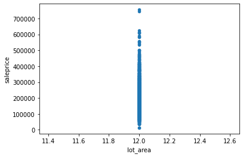

```python
# Scatter plot with lot_area on the x axis, and saleprice on the y axis
ames_df.plot(x = 'lot_area', y = 'saleprice', kind = 'scatter');
```

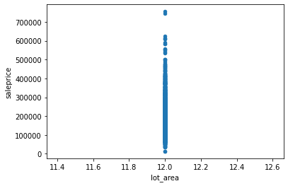

```python
lot_under_100k_sf = ames_df[ames_df['lot_area'] < 100000]
lot_under_100k_sf.plot(x = 'lot_area', y = 'saleprice', kind = 'scatter');
```

# 9 Finish

You’ve completed the first session! Take some time to play around with the code from today to get a feel for how it works, and when it doesn’t!